# Interactive graphics

Di Cook, Heike Hofmann  
3/31/2014

### Interactive graphics

- gridSVG
- iplots
- plumbr
- cranvas
- animint
- ggvis

### Get some data

```r
# Read the data from the web site
flu.data <- read.table("http://www.google.org/flutrends/us/data.txt",
                       skip=11, sep=",", header=TRUE)
# Get only states
flu.data <- flu.data[, c(1, 3:53)]

# Melt data, and rename variables
library(reshape)
flu.melt <- melt(flu.data, id.vars="Date")
library(lubridate)
flu.melt$Date <- as.Date(flu.melt$Date)
colnames(flu.melt)[2] <- "State"
colnames(flu.melt)[3] <- "FluSearches"
flu.melt$Month <- month(flu.melt$Date, label=TRUE)
flu.melt$Year <- factor(year(flu.melt$Date))
flu.melt$YDay <- yday(flu.melt$Date)
flu.13.14 <- subset(flu.melt, (Year=="2013"&YDay>200)|Year=="2014")
flu.13.14$days <- as.numeric(difftime(flu.13.14$Date, min(flu.13.14$Date), units="days"))
```

### Static plot

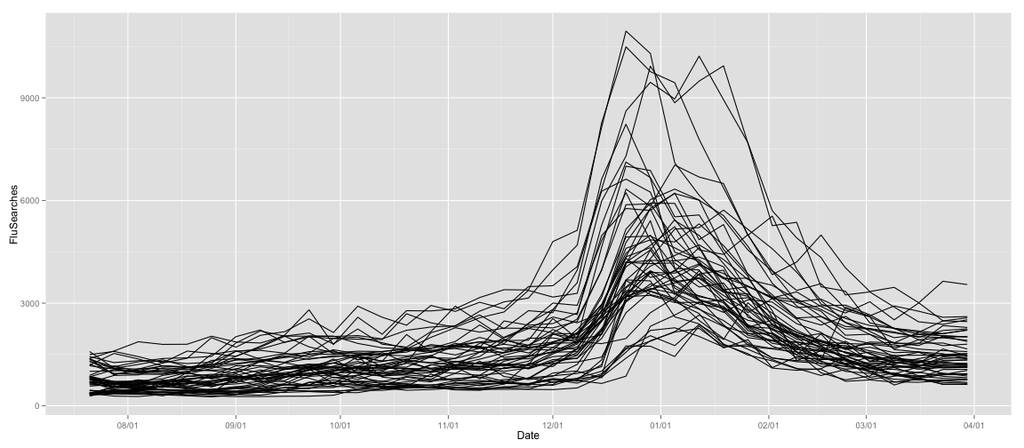

```r
library(ggplot2)
library(scales)
qplot(Date, FluSearches, data=flu.13.14, group=State, geom="line") +
  scale_x_date(breaks = date_breaks("1 month"), labels = date_format("%m/%d"))
```

### iplots

The `iplots` package provide interactive mosaic plots, bar plots, box plots, parallel plots, scatter plots and histograms that can be linked and color brushed. It is implemented through the Java GUI for R.

For simple explorations of data.

```
library(iplots)
iplot(flu.13.14$days, flu.13.14$FluSearches)
ibar(flu.13.14$State)
```

### iplots

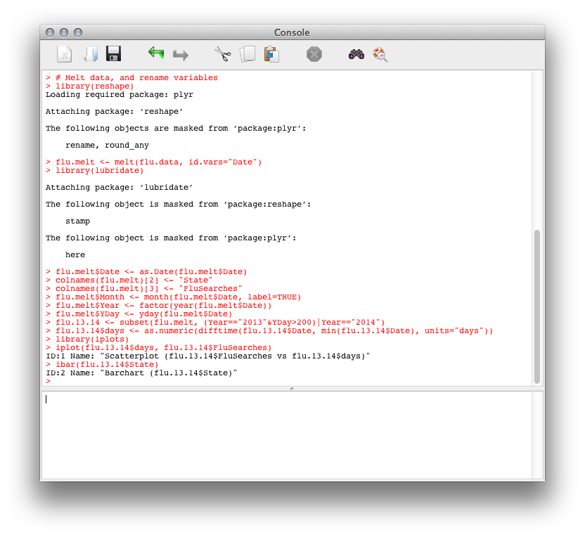

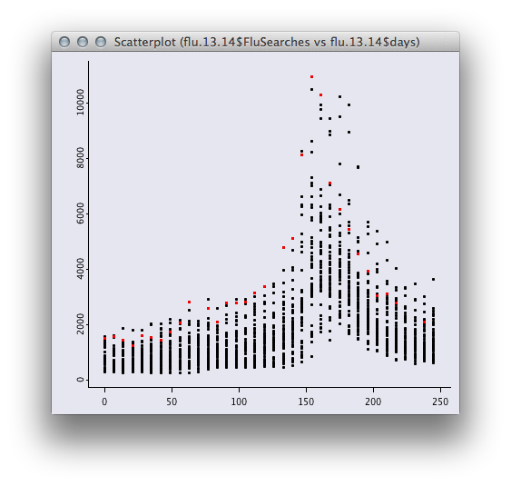

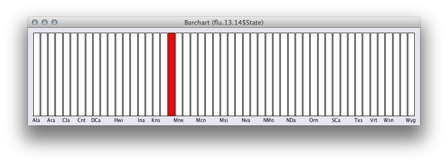

### cranvas

Cranvas provides interactive graphics throgh mutable objects.

```
library(cranvas)
library(maps)
flu.13.14$State <- tolower(flu.13.14$State)
flu.13.14$state <- gsub("[.]", " ", flu.13.14$State)
qflu <- qdata(flu.13.14)
qscatter(days, FluSearches, data=qflu)
record_selector(state, data=qflu)
qstate <- map_qdata("state")
qmap(qstate, linkto = qflu, linkby = "state")
```

### cranvas

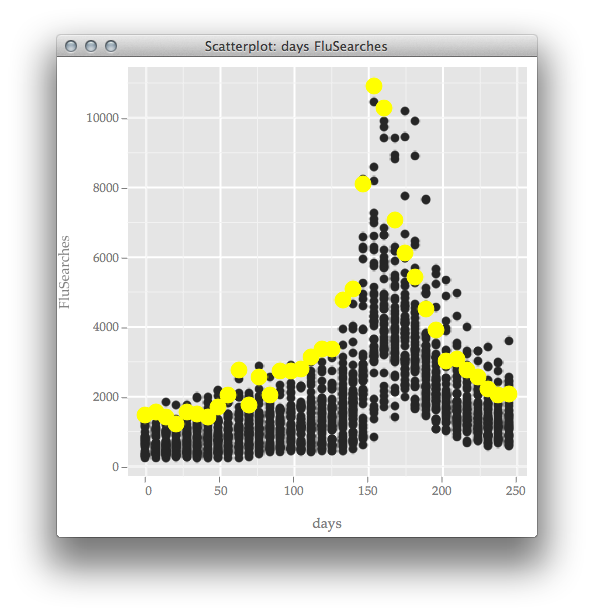

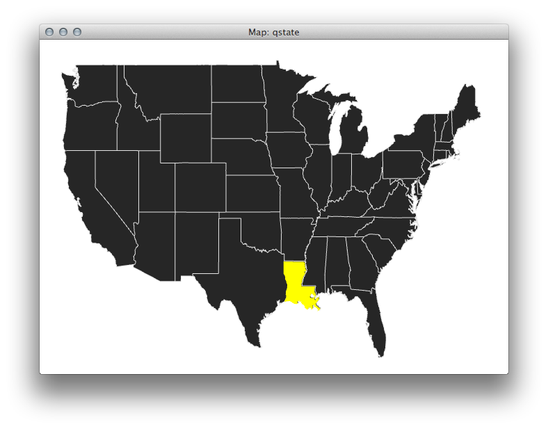

### cranvastime

Slice and dice time series

```
qtime(days, FluSearches, data=qflu, group="State")
```

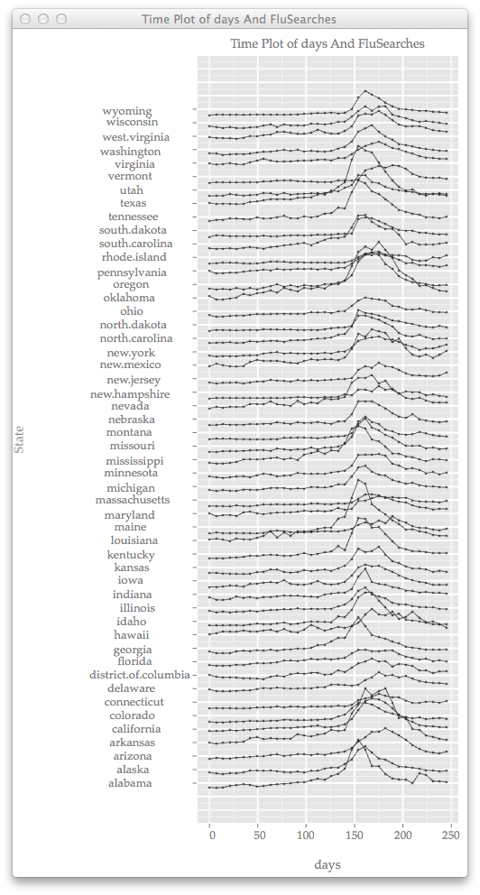

### What do we learn

- Peak flu season was around January for most states
- Some states have a second peak, eg Alabama
- Peak is longer for some states
- Peak season lags in some states relative to others (North/South?)

### Why?

- Interactive graphics enables exploration of data
- Multiple linked windows provides the ability to make connections between different aspects
- Connected to model fitting enables better diagnostics

### How does it work?

- Interactive graphics needs to listen to user actions and respond
- `iplots` achieves this by running Java, a full programming language, but the R event loop interferes with the listening, so a separate GUI, JGR, was built to circumvent this
- `cranvas` works by using a different type of data, mutaframes instead of dataframes
- `animint, ggvis` - reimplement graphics in javascript and then need a browser to view the plots

### cranvas

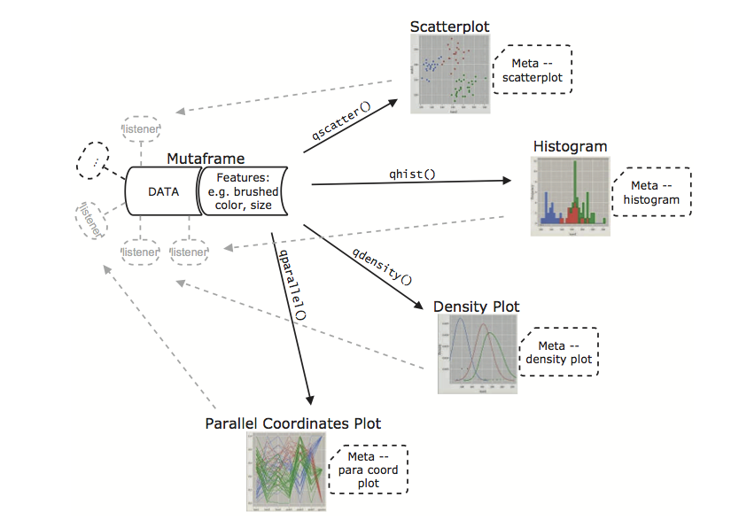

### plumbr

```r
library(plumbr)
mf <- mutaframe(x = 1:2 * pi)
df <- data.frame(x = 1:2 * pi)
c(mf$x[2], df$x[2])  # the 2nd elements in mf and df
```

```
[1] 6.283 6.283
```

```r
f <- function() {
  mf$x[2] <- 10
  df$x[2] <- 10
}
f()  # modified mf, but not df
c(mf$x[2], df$x[2])
```

```
[1] 10.000  6.283
```

Changes to the elements of a mutaframe can be made anywhere rgardless of the environment.

### plumbr

Useful for interactive graphics, because it triggers updates to plots: reactive programming.

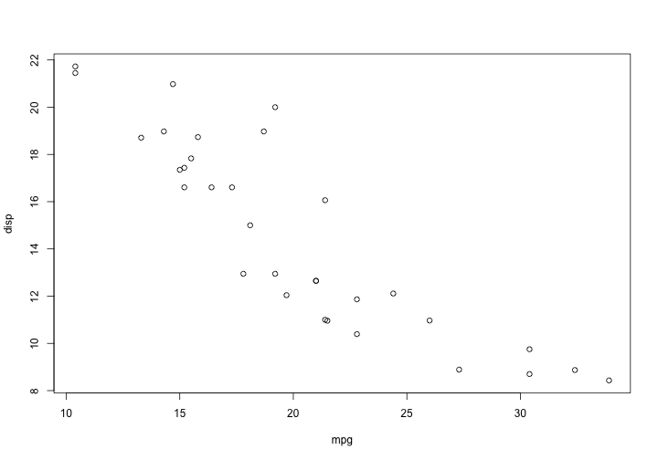

```r
mf <- mutaframe(mtcars)
add_listener(mf, function(i, j) {
  # i indicates the rows modified, and j indicates columns
  plot(disp ~ mpg, data = as.data.frame(mf))
})
mf$disp <- sqrt(mf$disp)
```

When the column `disp` is transformed the plot automatically updates.

### plumbr and cranvas

```r
library(cranvas)
head(flu.13.14)
```

```
          Date   State FluSearches Month Year YDay days
513 2013-07-21 Alabama         640   Jul 2013  202    0
514 2013-07-28 Alabama         549   Jul 2013  209    7
515 2013-08-04 Alabama         638   Aug 2013  216   14
516 2013-08-11 Alabama         888   Aug 2013  223   21
517 2013-08-18 Alabama         982   Aug 2013  230   28
518 2013-08-25 Alabama        1145   Aug 2013  237   35
```

```r
head(qdata(flu.13.14))
```

```
          Date   State FluSearches Month Year YDay days .brushed .visible
513 2013-07-21 Alabama         640   Jul 2013  202    0    FALSE     TRUE
514 2013-07-28 Alabama         549   Jul 2013  209    7    FALSE     TRUE
515 2013-08-04 Alabama         638   Aug 2013  216   14    FALSE     TRUE
516 2013-08-11 Alabama         888   Aug 2013  223   21    FALSE     TRUE
517 2013-08-18 Alabama         982   Aug 2013  230   28    FALSE     TRUE
518 2013-08-25 Alabama        1145   Aug 2013  237   35    FALSE     TRUE
    .color .border .size
513 gray15  gray15     4
514 gray15  gray15     4
515 gray15  gray15     4
516 gray15  gray15     4
517 gray15  gray15     4
518 gray15  gray15     4
```

### plumbr and cranvas

- This provides the ability to update plots, but does not listen to the user actions (mouse clicks, etc) on a plot.
- For this one needs to listen to mouse events, which is done using the graphics toolkit, Qt.
- Qt handles the mouse events and converts the graphical object selection into changes in the mutaframe object, which triggers a plot update.